# Pelangi Retail

Jodi Al Anshari Muttaqi

6/6/2020

# 1 Explanation

## 1.1 Brief

Welcome to my Rmd. This is my first LBB by using data from Retail.csv I hope you can understand it.

## 1.2 Data’s Point of View

This data contains sales record which include Ship Mode, Segment, Category, the profit or loss, etc. I called it PT. Pelangi Jaya. PT. Pelangi Jaya is a retail company who sells various items like Office equipments, furniture and technology stuff, etc. The customers are coming from different segment such as Corporate, Home Office until individual consumer. This company also could provide the convenience services for customers delivery which is suitable with their needs. ’ Note : Detail explanatory will be given at the end of content

# 2 Data Input

```r
# Make sure your data is placed in the same folder with your R project data
pelangi = read.csv("data_input/retail.csv")
```

## 2.1 Data Inspection

```r
head(pelangi)
```

```
##   Row.ID       Order.ID Order.Date Ship.Date      Ship.Mode Customer.ID
## 1      1 CA-2016-152156    11/8/16  11/11/16   Second Class    CG-12520
## 2      2 CA-2016-152156    11/8/16  11/11/16   Second Class    CG-12520
## 3      3 CA-2016-138688    6/12/16   6/16/16   Second Class    DV-13045
## 4      4 US-2015-108966   10/11/15  10/18/15 Standard Class    SO-20335
## 5      5 US-2015-108966   10/11/15  10/18/15 Standard Class    SO-20335
## 6      6 CA-2014-115812     6/9/14   6/14/14 Standard Class    BH-11710
##     Segment      Product.ID        Category Sub.Category
## 1  Consumer FUR-BO-10001798       Furniture    Bookcases
## 2  Consumer FUR-CH-10000454       Furniture       Chairs
## 3 Corporate OFF-LA-10000240 Office Supplies       Labels
## 4  Consumer FUR-TA-10000577       Furniture       Tables
## 5  Consumer OFF-ST-10000760 Office Supplies      Storage
## 6  Consumer FUR-FU-10001487       Furniture  Furnishings
##                                                       Product.Name    Sales
## 1                                Bush Somerset Collection Bookcase 261.9600
## 2      Hon Deluxe Fabric Upholstered Stacking Chairs, Rounded Back 731.9400
## 3        Self-Adhesive Address Labels for Typewriters by Universal  14.6200
## 4                    Bretford CR4500 Series Slim Rectangular Table 957.5775
## 5                                   Eldon Fold 'N Roll Cart System  22.3680
## 6 Eldon Expressions Wood and Plastic Desk Accessories, Cherry Wood  48.8600
##   Quantity Discount    Profit
## 1        2     0.00   41.9136
## 2        3     0.00  219.5820
## 3        2     0.00    6.8714
## 4        5     0.45 -383.0310
## 5        2     0.20    2.5164
## 6        7     0.00   14.1694
```

```r
tail(pelangi)
```

```
##      Row.ID       Order.ID Order.Date Ship.Date      Ship.Mode Customer.ID
## 9989   9989 CA-2017-163629   11/17/17  11/21/17 Standard Class    RA-19885
## 9990   9990 CA-2014-110422    1/21/14   1/23/14   Second Class    TB-21400
## 9991   9991 CA-2017-121258    2/26/17    3/3/17 Standard Class    DB-13060
## 9992   9992 CA-2017-121258    2/26/17    3/3/17 Standard Class    DB-13060
## 9993   9993 CA-2017-121258    2/26/17    3/3/17 Standard Class    DB-13060
## 9994   9994 CA-2017-119914     5/4/17    5/9/17   Second Class    CC-12220
##        Segment      Product.ID        Category Sub.Category
## 9989 Corporate TEC-PH-10004006      Technology       Phones
## 9990  Consumer FUR-FU-10001889       Furniture  Furnishings
## 9991  Consumer FUR-FU-10000747       Furniture  Furnishings
## 9992  Consumer TEC-PH-10003645      Technology       Phones
## 9993  Consumer OFF-PA-10004041 Office Supplies        Paper
## 9994  Consumer OFF-AP-10002684 Office Supplies   Appliances
##                                                                   Product.Name
## 9989                                           Panasonic KX - TS880B Telephone
## 9990                                                    Ultra Door Pull Handle
## 9991                        Tenex B1-RE Series Chair Mats for Low Pile Carpets
## 9992                                                     Aastra 57i VoIP phone
## 9993                         It's Hot Message Books with Stickers, 2 3/4" x 5"
## 9994 Acco 7-Outlet Masterpiece Power Center, Wihtout Fax/Phone Line Protection
##        Sales Quantity Discount  Profit
## 9989 206.100        5      0.0 55.6470
## 9990  25.248        3      0.2  4.1028
## 9991  91.960        2      0.0 15.6332
## 9992 258.576        2      0.2 19.3932
## 9993  29.600        4      0.0 13.3200
## 9994 243.160        2      0.0 72.9480
```

```r
dim(pelangi)
```

```
## [1] 9994   15
```

```r
names(pelangi)
```

```
##  [1] "Row.ID"       "Order.ID"     "Order.Date"   "Ship.Date"    "Ship.Mode"
##  [6] "Customer.ID"  "Segment"      "Product.ID"   "Category"     "Sub.Category"
## [11] "Product.Name" "Sales"        "Quantity"     "Discount"     "Profit"
```

Based on data inspection above, we can conclude that : * Pelangi data contains 9994 of rows and 15 of coloumns * Each of column name : “Row.ID”, “Order.ID”, “Order.Date”, “Ship.Date”, “Ship.Mode”, “Customer.ID”, “Segment”,“Product.ID”, “Category”, “Sub.Category”, “Product.Name”, “Sales”, “Quantity”, “Discount”, “Profit”

## 2.2 Data Cleansing

```r
# Check data type for each column
str(pelangi)
```

```
## 'data.frame':    9994 obs. of  15 variables:
##  $ Row.ID      : int  1 2 3 4 5 6 7 8 9 10 ...
##  $ Order.ID    : chr  "CA-2016-152156" "CA-2016-152156" "CA-2016-138688" "US-2015-108966" ...
##  $ Order.Date  : chr  "11/8/16" "11/8/16" "6/12/16" "10/11/15" ...
##  $ Ship.Date   : chr  "11/11/16" "11/11/16" "6/16/16" "10/18/15" ...
##  $ Ship.Mode   : chr  "Second Class" "Second Class" "Second Class" "Standard Class" ...
##  $ Customer.ID : chr  "CG-12520" "CG-12520" "DV-13045" "SO-20335" ...
##  $ Segment     : chr  "Consumer" "Consumer" "Corporate" "Consumer" ...
##  $ Product.ID  : chr  "FUR-BO-10001798" "FUR-CH-10000454" "OFF-LA-10000240" "FUR-TA-10000577" ...
##  $ Category    : chr  "Furniture" "Furniture" "Office Supplies" "Furniture" ...
##  $ Sub.Category: chr  "Bookcases" "Chairs" "Labels" "Tables" ...
##  $ Product.Name: chr  "Bush Somerset Collection Bookcase" "Hon Deluxe Fabric Upholstered Stacking Chairs, Rounded Back" "Self-Adhesive Address Labels for Typewriters by Universal" "Bretford CR4500 Series Slim Rectangular Table" ...
##  $ Sales       : num  262 731.9 14.6 957.6 22.4 ...
##  $ Quantity    : int  2 3 2 5 2 7 4 6 3 5 ...
##  $ Discount    : num  0 0 0 0.45 0.2 0 0 0.2 0.2 0 ...
##  $ Profit      : num  41.91 219.58 6.87 -383.03 2.52 ...
```

```r
# From this result, we find some of data type not in the corect type. we need to convert it into corect type (data coertion)
pelangi$Row.ID <- as.character(pelangi$Row.ID)
pelangi$Order.ID<- as.character (pelangi$Order.ID)
pelangi$Order.Date<- as.Date(pelangi$Order.Date, "%m/%d/%y")
pelangi$Ship.Date <- as.Date(pelangi$Ship.Date, "%m/%d/%y")
pelangi$Customer.ID<-as.character(pelangi$Customer.ID)
pelangi$Product.ID<- as.character(pelangi$Product.ID)
pelangi$Product.Name<-as.character(pelangi$Product.Name)

str(pelangi)
```

```
## 'data.frame':    9994 obs. of  15 variables:
##  $ Row.ID      : chr  "1" "2" "3" "4" ...
##  $ Order.ID    : chr  "CA-2016-152156" "CA-2016-152156" "CA-2016-138688" "US-2015-108966" ...
##  $ Order.Date  : Date, format: "2016-11-08" "2016-11-08" ...
##  $ Ship.Date   : Date, format: "2016-11-11" "2016-11-11" ...
##  $ Ship.Mode   : chr  "Second Class" "Second Class" "Second Class" "Standard Class" ...
##  $ Customer.ID : chr  "CG-12520" "CG-12520" "DV-13045" "SO-20335" ...
##  $ Segment     : chr  "Consumer" "Consumer" "Corporate" "Consumer" ...
##  $ Product.ID  : chr  "FUR-BO-10001798" "FUR-CH-10000454" "OFF-LA-10000240" "FUR-TA-10000577" ...
##  $ Category    : chr  "Furniture" "Furniture" "Office Supplies" "Furniture" ...
##  $ Sub.Category: chr  "Bookcases" "Chairs" "Labels" "Tables" ...
##  $ Product.Name: chr  "Bush Somerset Collection Bookcase" "Hon Deluxe Fabric Upholstered Stacking Chairs, Rounded Back" "Self-Adhesive Address Labels for Typewriters by Universal" "Bretford CR4500 Series Slim Rectangular Table" ...
##  $ Sales       : num  262 731.9 14.6 957.6 22.4 ...
##  $ Quantity    : int  2 3 2 5 2 7 4 6 3 5 ...
##  $ Discount    : num  0 0 0 0.45 0.2 0 0 0.2 0.2 0 ...
##  $ Profit      : num  41.91 219.58 6.87 -383.03 2.52 ...
```

Data type is correct.

```r
#Missing value check
colSums(is.na(pelangi))
```

```
##       Row.ID     Order.ID   Order.Date    Ship.Date    Ship.Mode  Customer.ID
##            0            0            0            0            0            0
##      Segment   Product.ID     Category Sub.Category Product.Name        Sales
##            0            0            0            0            0            0
##     Quantity     Discount       Profit
##            0            0            0
```

```r
anyNA(pelangi)
```

```
## [1] FALSE
```

Done. No missing value here.

# 3 Data Explanation

```r
summary(pelangi)
```

```
##     Row.ID            Order.ID           Order.Date
##  Length:9994        Length:9994        Min.   :2014-01-03
##  Class :character   Class :character   1st Qu.:2015-05-23
##  Mode  :character   Mode  :character   Median :2016-06-26
##                                        Mean   :2016-04-30
##                                        3rd Qu.:2017-05-14
##                                        Max.   :2017-12-30
##    Ship.Date           Ship.Mode         Customer.ID          Segment
##  Min.   :2014-01-07   Length:9994        Length:9994        Length:9994
##  1st Qu.:2015-05-27   Class :character   Class :character   Class :character
##  Median :2016-06-29   Mode  :character   Mode  :character   Mode  :character
##  Mean   :2016-05-03
##  3rd Qu.:2017-05-18
##  Max.   :2018-01-05
##   Product.ID          Category         Sub.Category       Product.Name
##  Length:9994        Length:9994        Length:9994        Length:9994
##  Class :character   Class :character   Class :character   Class :character
##  Mode  :character   Mode  :character   Mode  :character   Mode  :character
##
##
##
##      Sales              Quantity        Discount          Profit
##  Min.   :    0.444   Min.   : 1.00   Min.   :0.0000   Min.   :-6599.978
##  1st Qu.:   17.280   1st Qu.: 2.00   1st Qu.:0.0000   1st Qu.:    1.729
##  Median :   54.490   Median : 3.00   Median :0.2000   Median :    8.666
##  Mean   :  229.858   Mean   : 3.79   Mean   :0.1562   Mean   :   28.657
##  3rd Qu.:  209.940   3rd Qu.: 5.00   3rd Qu.:0.2000   3rd Qu.:   29.364
##  Max.   :22638.480   Max.   :14.00   Max.   :0.8000   Max.   : 8399.976
```

1. PT. Pelangi Jaya received first order on January 2014 and last order occured on December 2017.
2. The highest sales was around 22638 and the lowest sales was 0.444.
3. The average discount received by customer was 15,62%.
4. PT. Pelangi Jaya got the highest profit of 8399,976 and loss about -6599,978.
5. The lowest order received was 1 and average order was 3,79.

Check the Outlier by Profit

```r
aggregate(Profit~Segment,pelangi,mean)
```

```
##       Segment   Profit
## 1    Consumer 25.83687
## 2   Corporate 30.45667
## 3 Home Office 33.81866
```

```r
aggregate(Profit~Segment,pelangi,var)
```

```
##       Segment   Profit
## 1    Consumer 58851.86
## 2   Corporate 53817.63
## 3 Home Office 45105.89
```

```r
aggregate(Profit~Segment,pelangi,sd)
```

```
##       Segment   Profit
## 1    Consumer 242.5940
## 2   Corporate 231.9863
## 3 Home Office 212.3815
```

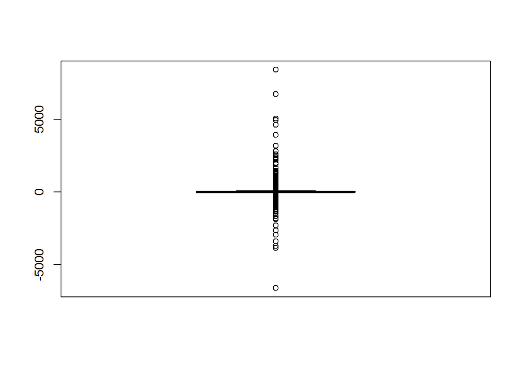

```r
boxplot(pelangi$Profit)
```

Based on result above, we find some posibilities that there are outliers, but from our calculation, Sd value is around 200 ( my oppinion it can be still be tolerated), so it can be continued.

# 4 Data Manipulation

1.Which category has the biggest Sales ?

```r
Big_sales <- aggregate(formula = Sales ~ Category, data = pelangi, FUN = sum)
Big_sales[order(Big_sales$Sales, decreasing = T),]
```

```
##          Category    Sales
## 3      Technology 836154.0
## 1       Furniture 741999.8
## 2 Office Supplies 719047.0
```

Answer: Technology

```r
subcat <- pelangi[pelangi$Quantity>10 & pelangi$Ship.Mode=="First Class",]
subcat
```

```
##      Row.ID       Order.ID Order.Date  Ship.Date   Ship.Mode Customer.ID
## 1364   1364 US-2017-155425 2017-11-10 2017-11-11 First Class    AB-10600
## 1597   1597 CA-2017-132234 2017-10-16 2017-10-18 First Class    MY-17380
## 2215   2215 CA-2017-129378 2017-10-01 2017-10-02 First Class    NS-18505
## 3296   3296 CA-2017-113418 2017-10-01 2017-10-03 First Class    CM-12655
## 5525   5525 CA-2016-147123 2016-12-10 2016-12-12 First Class    SJ-20125
## 7998   7998 US-2017-105998 2017-11-03 2017-11-05 First Class    CR-12580
## 8509   8509 CA-2015-135853 2015-12-11 2015-12-14 First Class    CA-12775
## 8880   8880 US-2015-107944 2015-03-23 2015-03-25 First Class    AM-10360
## 9057   9057 CA-2015-160227 2015-11-02 2015-11-04 First Class    ED-13885
## 9883   9883 CA-2014-153927 2014-08-12 2014-08-13 First Class    LL-16840
##          Segment      Product.ID        Category Sub.Category
## 1364   Corporate OFF-BI-10001036 Office Supplies      Binders
## 1597   Corporate FUR-FU-10001290       Furniture  Furnishings
## 2215    Consumer OFF-BI-10001922 Office Supplies      Binders
```

[output cut: 29 more lines]

```r
#10
```

Answer: 10

3. Which segment bought most furniture ?

```r
furn <- pelangi[pelangi$Category=="Furniture",]
round(prop.table(table(furn$Segment))*100,2)
```

```
##
##    Consumer   Corporate Home Office
##       52.48       30.46       17.07
```

Answer: Consumer

4. Which category that has max loss ?

```r
pelangi[pelangi$Profit == min(pelangi$Profit), ]
```

```
##      Row.ID       Order.ID Order.Date  Ship.Date      Ship.Mode Customer.ID
## 7773   7773 CA-2016-108196 2016-11-25 2016-12-02 Standard Class    CS-12505
##       Segment      Product.ID   Category Sub.Category
## 7773 Consumer TEC-MA-10000418 Technology     Machines
##                                   Product.Name    Sales Quantity Discount
## 7773 Cubify CubeX 3D Printer Double Head Print 4499.985        5      0.7
##         Profit
## 7773 -6599.978
```

Answer: Technology

5. Which sub category that has max profit ?

```r
pelangi[pelangi$Sales == max(pelangi$Profit), ]
```

```
##      Row.ID       Order.ID Order.Date  Ship.Date      Ship.Mode Customer.ID
## 6426   6426 CA-2016-143714 2016-05-23 2016-05-27 Standard Class    CC-12370
##       Segment      Product.ID   Category Sub.Category
## 6426 Consumer TEC-CO-10004722 Technology      Copiers
##                               Product.Name    Sales Quantity Discount   Profit
## 6426 Canon imageCLASS 2200 Advanced Copier 8399.976        4      0.4 1119.997
```

6. How many phones that PT. Pelangi Jaya sold ?

```r
phone <- pelangi[pelangi$Sub.Category=="Phones",]
sum(phone$Quantity)
```

```
## [1] 3289
```

7. How much profit did PT. Pelangi Jaya make by selling machines ?

```r
Machine <- pelangi[pelangi$Sub.Category=="Machines",]
aggregate(formula= Profit ~ Sub.Category, data = Machine, FUN = sum)
```

```
##   Sub.Category   Profit
## 1     Machines 3384.757
```

8. How much profit did PT. Pelangi Jaya make based on segment and ship mode ?

```r
xtabs(Profit~Segment+Ship.Mode,pelangi)
```

```
##              Ship.Mode
## Segment       First Class  Same Day Second Class Standard Class
##   Consumer      21374.044  9874.205    24946.911      77924.049
##   Corporate     14464.472  1818.142    18225.713      57470.807
##   Home Office   13131.324  4199.412    14274.011      28693.932
```

9. Which categories were the most sold ?

```r
xtabs(Quantity~Category,pelangi)
```

```
## Category
##       Furniture Office Supplies      Technology
##            8028           22906            6939
```

10. Which sub categories were the most sold ?

```r
xtabs(Quantity~Sub.Category,pelangi)
```

```
## Sub.Category
## Accessories  Appliances         Art     Binders   Bookcases      Chairs
##        2976        1729        3000        5974         868        2356
##     Copiers   Envelopes   Fasteners Furnishings      Labels    Machines
##         234         906         914        3563        1400         440
##       Paper      Phones     Storage    Supplies      Tables
##        5178        3289        3158         647        1241
```

11. Which sub category generates max average profit and loss ?

```r
proflos <- aggregate(formula = Profit ~ Sub.Category, data = pelangi, FUN = mean)
proflos[order(proflos$Profit, decreasing = T),]
```

```
##    Sub.Category     Profit
## 7       Copiers 817.909190
## 1   Accessories  54.111788
## 14       Phones  50.073938
## 6        Chairs  43.095894
## 2    Appliances  38.922758
## 12     Machines  29.432669
## 8     Envelopes  27.418019
## 15      Storage  25.152277
## 13        Paper  24.856620
## 4       Binders  19.843574
## 11       Labels  15.236962
## 10  Furnishings  13.645918
## 3           Art   8.200737
## 9     Fasteners   4.375660
## 16     Supplies  -6.258418
## 5     Bookcases -15.230509
## 17       Tables -55.565771
```

Copiers and Tables

# 5 Explanatory Text & Business Recomendation

Based on the exploratory data analysis above, we can conclude that: PT. Pelangi Jaya gains most sales from technology category. Max loss comes from technlogy category.Binders were the best selling in sub category. The company sold more office supplies category than other categories. Standard class was the most commonly used by all segments.

Recomendation: